# MSDS 6373 Covid Project

Balaji Avvaru

8/4/2020

### Time series analysis on COVID data for Washing state

### Response variable is number of new daily cases

### EDA

1. Identify yourself and your partner (if applicable). Goal 1
2. Describe the Data Set / Time Series (Who, What, When, Where, Why and How) Goal 1
3. Stationary / Non-Stationary Goal 2
4. ACFs and Spectral Densities just to explore Goal 2
5. At least 2 (total) candidate ARMA / ARIMA models (univariate) Goal 2 a. The models in factored form or at least separate the stationary and non- stationary factors with standard deviation or variance of the white noise. b. AIC c. ASE (Rolling window) d. Visualization of Forecasts (Short and Long Term / State and National)
6. Strategy / Plans for the rest of the analysis.

****** Read Covid data ******** Covid data downloded from : https://covidtracking.com/data/download

```r
setwd("C:/Users/BelajiAvvaru/Desktop/Docs/SMU/MSDS 6373/Project/")
#Read in the data
Covid19data <- read.csv(file.choose(),header=TRUE)
dim(Covid19data)
```

```
## [1] 195  41
```

****** Read mobility data ******** Mobility data downloded from https://data.bts.gov/Research-and-Statistics/Trips-by-Distance/w96p-f2qv

```r
mobilitydata <- read.csv(file.choose(),header=TRUE)
dim(mobilitydata)
```

```
## [1] 1826968      19
```

### Describe Covid Data Set

This is a time series data set downloaded from https://covidtracking.com/data/download. The data set is a record of the cumulative number of positive cases, cumulative number of negative cases, cumulative number of death over the time for all states in the United States. This was collected from January 22nd, 2020 through august 3rd, 2020 and consists of 195 entries for Washington state. Computed number of new cases, total daily cases and positive percentage

There are three different correlation structures in the covid data, due to lack of tests and also lack of reporing, initial correlation structure is one kind. From 02/29 to 06/01, there is another correlation structure. After 06/01 I see different correlation structure as number of test increased which results in more number of positive cases. forecasting will following latest trend, using data from 06/01 to 07/25 which will helpful in creating accurate model for forecasting with latest trends.

*** tidy covid data **

```r
Coviddata = Covid19data[ , c('date', 'state', 'positive', 'negative', 'death')]
# Question on interest is to analyze Washington state Covid data, get Washington state data after 06/15/2020
Coviddata_WA <- Coviddata %>% filter(date >= 20200601 & date <= 20200725)
# Arrange the data in the ascending order based on date
Coviddata_WA <-  Coviddata_WA[order(Coviddata_WA$date),]
# Create new column for "new cases" by taking first difference
Coviddata_WA <- Coviddata_WA %>% mutate(new_cases = c(positive[1],diff(positive)))
# Create new column for "Positive percentage"
Coviddata_WA$positivePer <- (Coviddata_WA$positive / (Coviddata_WA$positive + Coviddata_WA$negative)) * 100
# create new column for new negative cases
Coviddata_WA <- Coviddata_WA %>% mutate(new_negative = c(negative[1],diff(negative)))
# create new column for total cases
Coviddata_WA$totalcases = Coviddata_WA$new_cases + Coviddata_WA$new_negative
Coviddata_WA = transform(Coviddata_WA, date=as.Date(as.character(date), "%Y%m%d"))

Coviddata_WA$new_cases[1] = 398
Coviddata_WA$totalcases[1] = 11398
```

### Describe Mobility Data Set

This is a daily data set downloaded from https://data.bts.gov/Research-and-Statistics/Trips-by-Distance/w96p-f2qv. The data set is a record of the number of people staying at home, number of people not staying at home, number of people had trips less than 1 mile, number of people had trips between 1 and 3 miles, number of people had trips between 3 and 5 miles, number of people had trips between 5 and 10 miles and number of people had trips between 10 and 25 miles. Used this data set in multivariate analysis to better forecast number new Covid cases in Washington state and US.

*** tidy mobility data **

```r
mobilitydata2020 = mobilitydata[ , c('Date', 'Level', 'State.Postal.Code',  'Population.Staying.at.Home',
                                     'Population.Not.Staying.at.Home', 'Number.of.Trips',
                                     'Number.of.Trips..1', 'Number.of.Trips.3.5',
                                     'Number.of.Trips.1.3', 'Number.of.Trips.5.10',
                                     'Number.of.Trips.10.25')]

mobilitydata2020$Date = as.Date(mobilitydata2020$Date, format="%Y/%m/%d")

# Question on interest is to analyze Washington state Covid data, get Washington state data after 02/29/2020
mobilitydata2020_WA <- mobilitydata2020 %>% filter(Level == 'County' & State.Postal.Code == 'WA' & Date >= '2020-06-01')
# Arrange the data in ascending order
mobilitydata2020_WA <-  mobilitydata2020_WA[order(mobilitydata2020_WA$Date),]
dim(mobilitydata2020_WA)
```

```
## [1] 2145   11
```

```r
# Group by mobility data
mobilitydata2020_WA_Sum <- mobilitydata2020_WA %>% dplyr::group_by(Date) %>%
  dplyr::summarize(athome = sum(Population.Staying.at.Home),
            notathome = sum(Population.Not.Staying.at.Home),
            num_trips = sum(Number.of.Trips),
            tripslessthan1mile = sum(Number.of.Trips..1),
            trips1to3miles = sum(Number.of.Trips.1.3),
            trips3to5miles = sum (Number.of.Trips.3.5),
            trips5to10miles = sum(Number.of.Trips.5.10),
            trips10to25miles = sum (Number.of.Trips.10.25))
## data is missing for July 4th week from 06/28 to 7/4. Impute mean values for these dates
NA2mean <- function(x) replace(x, is.na(x), mean(x, na.rm = TRUE))
mobilitydata2020_WA_Sum <- replace(mobilitydata2020_WA_Sum, TRUE, lapply(mobilitydata2020_WA_Sum, NA2mean))

# verify any null values
new_DF <- mobilitydata2020_WA_Sum[rowSums(is.na(mobilitydata2020_WA_Sum)) > 0,]
new_DF
```

```
## # A tibble: 0 x 9
## # ... with 9 variables: Date <date>, athome <dbl>, notathome <dbl>,
## #   num_trips <dbl>, tripslessthan1mile <dbl>, trips1to3miles <dbl>,
## #   trips3to5miles <dbl>, trips5to10miles <dbl>, trips10to25miles <dbl>
```

*** Merge Covid data and Mobility data by date **

```r
Covid_mobility_WA <- merge(Coviddata_WA, mobilitydata2020_WA_Sum, by.x = "date",
                   by.y = "Date", all.x = TRUE)

dim(Covid_mobility_WA)
```

```
## [1] 55 17
```

### check whether data comes from stationary model or non-Stationary model

Constant Variance: Over this time frame, there is evidence that the condition is not met because the variance appears fluctuating over the time.

Constant Auto correlations: Judging from the ACFs of the first half and the second half of the series, we see that there is strong evidence that the autocorrelations depend on time.

```r
dim(Coviddata_WA)
```

```
## [1] 55  9
```

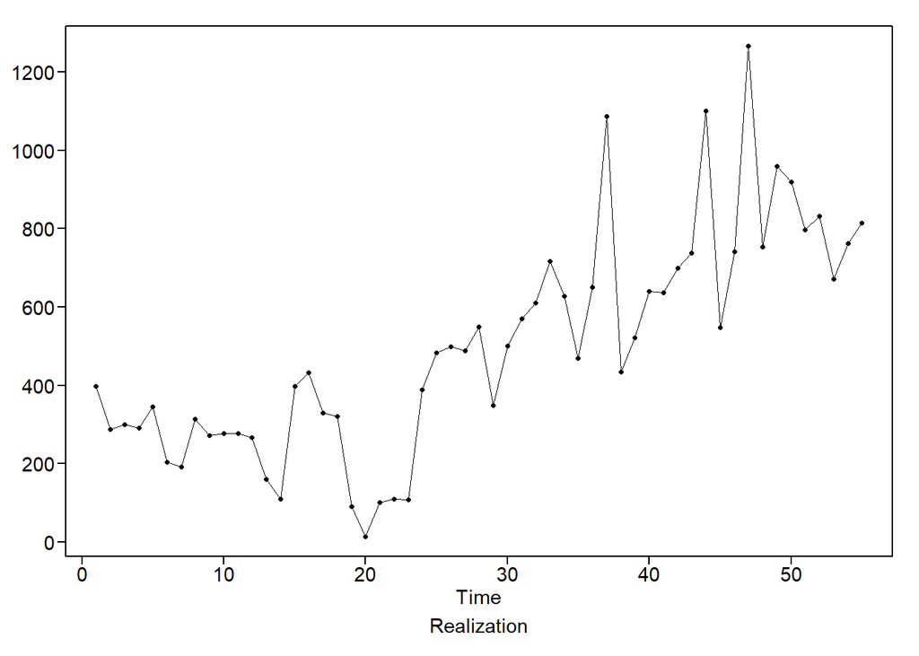

```r
# New cases Realization
plotts.wge(Coviddata_WA$new_cases)
```

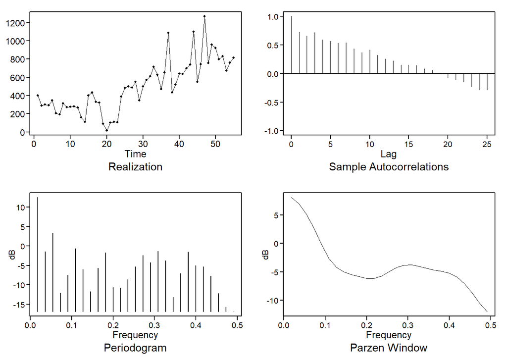

```
## $autplt
##  [1]  1.00000000  0.72808726  0.65880950  0.71669513  0.59531278  0.56750061
##  [7]  0.53171669  0.54223608  0.43461379  0.37174306  0.41799247  0.32273223
## [13]  0.25794639  0.22475646  0.15179515  0.15264370  0.14431577  0.08349307
## [19]  0.05972672  0.01010200 -0.07523448 -0.10574078 -0.14303607 -0.23465757
## [25] -0.28197731 -0.28242847
##
## $freq
##  [1] 0.01818182 0.03636364 0.05454545 0.07272727 0.09090909 0.10909091
##  [7] 0.12727273 0.14545455 0.16363636 0.18181818 0.20000000 0.21818182
## [13] 0.23636364 0.25454545 0.27272727 0.29090909 0.30909091 0.32727273
## [19] 0.34545455 0.36363636 0.38181818 0.40000000 0.41818182 0.43636364
## [25] 0.45454545 0.47272727 0.49090909
##
## $db
##  [1]  12.4934974  -1.4775728   3.2881474 -12.1215385  -7.4453210  -0.6277917
##  [7]  -5.9987191 -11.7237767  -5.7518707  -1.7144382 -10.6754598 -10.7830485
## [13]  -8.6650233  -5.3267189  -2.3891144  -4.2399362  -1.2930448  -3.8041914
## [19] -13.1951816  -7.0922979  -1.5737086  -5.0420187  -5.2932210  -7.7546246
## [25] -12.1683438 -15.6687086 -16.9001499
##
## $dbz
##  [1]   8.0786061   6.9750345   5.1460821   2.6680899  -0.1700473  -2.6918727
##  [7]  -4.2433419  -5.0050301  -5.4750215  -5.8559860  -6.1426315  -6.1757657
## [13]  -5.7611674  -4.9971842  -4.2510090  -3.8141099  -3.7689366  -4.0243107
## [19]  -4.3822169  -4.6678679  -4.8887321  -5.2326798  -5.9141770  -7.0641939
## [25]  -8.6868752 -10.5659635 -12.0210834
```

```r
# Check ACF and Spectral density plots
plotts.sample.wge(Coviddata_WA$new_cases)
```

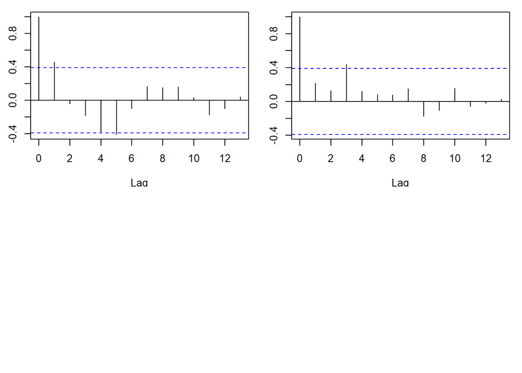

```r
# Auto correlations of first half of data
acf(Coviddata_WA$new_cases[1:25])
# Auto correlations of second half of data
acf(Coviddata_WA$new_cases[26:50])
```

### UNIVARIATE ANALYSIS

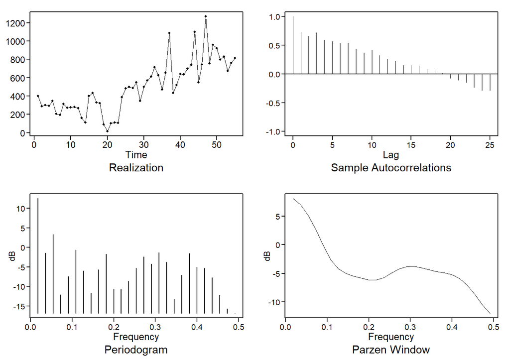

```
## $autplt
##  [1]  1.00000000  0.72808726  0.65880950  0.71669513  0.59531278  0.56750061
##  [7]  0.53171669  0.54223608  0.43461379  0.37174306  0.41799247  0.32273223
## [13]  0.25794639  0.22475646  0.15179515  0.15264370  0.14431577  0.08349307
## [19]  0.05972672  0.01010200 -0.07523448 -0.10574078 -0.14303607 -0.23465757
## [25] -0.28197731 -0.28242847
##
## $freq
##  [1] 0.01818182 0.03636364 0.05454545 0.07272727 0.09090909 0.10909091
##  [7] 0.12727273 0.14545455 0.16363636 0.18181818 0.20000000 0.21818182
## [13] 0.23636364 0.25454545 0.27272727 0.29090909 0.30909091 0.32727273
## [19] 0.34545455 0.36363636 0.38181818 0.40000000 0.41818182 0.43636364
## [25] 0.45454545 0.47272727 0.49090909
##
## $db
##  [1]  12.4934974  -1.4775728   3.2881474 -12.1215385  -7.4453210  -0.6277917
##  [7]  -5.9987191 -11.7237767  -5.7518707  -1.7144382 -10.6754598 -10.7830485
## [13]  -8.6650233  -5.3267189  -2.3891144  -4.2399362  -1.2930448  -3.8041914
## [19] -13.1951816  -7.0922979  -1.5737086  -5.0420187  -5.2932210  -7.7546246
## [25] -12.1683438 -15.6687086 -16.9001499
##
## $dbz
##  [1]   8.0786061   6.9750345   5.1460821   2.6680899  -0.1700473  -2.6918727
##  [7]  -4.2433419  -5.0050301  -5.4750215  -5.8559860  -6.1426315  -6.1757657
## [13]  -5.7611674  -4.9971842  -4.2510090  -3.8141099  -3.7689366  -4.0243107
## [19]  -4.3822169  -4.6678679  -4.8887321  -5.2326798  -5.9141770  -7.0641939
## [25]  -8.6868752 -10.5659635 -12.0210834
```

```r
## Auto correlations are slowly damping.
## Dickey-Fuller test to see whether there is any root on unit circle or not
plotts.sample.wge(Coviddata_WA$new_cases)
```

```r
adf.test(Coviddata_WA$new_cases)
```

```
##
##  Augmented Dickey-Fuller Test
##
## data:  Coviddata_WA$new_cases
## Dickey-Fuller = -2.8675, Lag order = 3, p-value = 0.225
## alternative hypothesis: stationary
```

```r
## p-value = 0.225, fail to reject null, which is evident that there is a root on unit circle. Proceed with ARIMA model

Coviddata_WA.d1 = artrans.wge(Coviddata_WA$new_cases,phi.tr = 1)
```

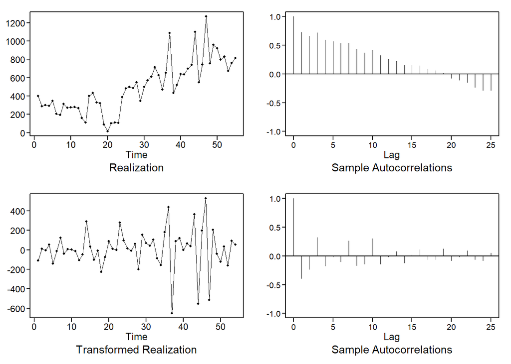

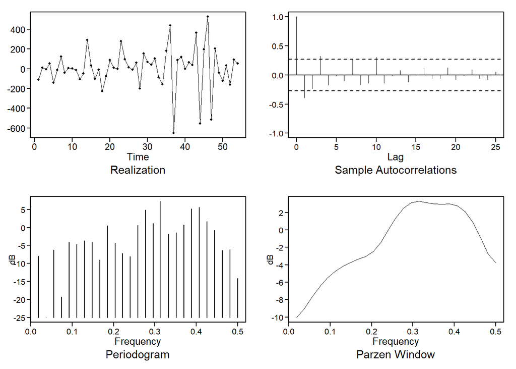

```
## $autplt
##  [1]  1.00000000 -0.39079124 -0.23380628  0.32139381 -0.17509761 -0.01122883
##  [7] -0.09844950  0.26139967 -0.16528831 -0.13760569  0.30021135 -0.14175119
## [13] -0.01639791  0.07762561 -0.12180976  0.01772472  0.11273242 -0.06066236
## [19] -0.05745612  0.12505001 -0.07787054 -0.01144188  0.08954759 -0.05932518
## [25] -0.08152318  0.05196893
##
## $freq
##  [1] 0.01851852 0.03703704 0.05555556 0.07407407 0.09259259 0.11111111
##  [7] 0.12962963 0.14814815 0.16666667 0.18518519 0.20370370 0.22222222
## [13] 0.24074074 0.25925926 0.27777778 0.29629630 0.31481481 0.33333333
## [19] 0.35185185 0.37037037 0.38888889 0.40740741 0.42592593 0.44444444
## [25] 0.46296296 0.48148148 0.50000000
##
## $db
##  [1]  -8.0056164 -25.0667006  -6.2881404 -19.3052516  -4.1295992  -4.6118544
##  [7]  -3.7206392  -4.1030891  -9.0373501   0.4615206  -4.3025932  -7.1655349
## [13]  -8.0160863   0.5890250   4.8438955   1.1674526   7.2627955  -1.8544351
## [19]  -1.3880701   0.7406690   5.1398472   5.6272986   1.6389860  -0.8496648
## [25]  -6.3614327  -6.1268388 -14.1778708
##
## $dbz
##  [1] -10.06616523  -9.02625247  -7.73603217  -6.51898126  -5.52849245
##  [6]  -4.77368483  -4.19286408  -3.73123820  -3.36591124  -3.02522021
## [11]  -2.47697781  -1.44923120  -0.01375307   1.42512196   2.51940025
## [16]   3.12737428   3.27909288   3.14576391   2.98496951   2.96187932
## [21]   2.97906161   2.77328539   2.11726278   0.89744364  -0.85462216
## [26]  -2.77074725  -3.73014025
```

```r
## ACFs of  differenced  data with d=1 doesn't look like white
plotts.sample.wge(Coviddata_WA.d1, arlimits = T)
```

```r
# use AIC5 to get lowest AIC to model the differenced data
aic5.wge(Coviddata_WA.d1, p=0:7, q=0:2,type="aic")
```

```
## ---------WORKING... PLEASE WAIT...
##
##
## Five Smallest Values of  aic
```

```
##       p    q        aic
## 20    6    1   10.30790
## 19    6    0   10.31749
## 2     0    1   10.32173
## 22    7    0   10.32326
## 7     2    0   10.32381
```

```r
## Top 2 models are ARMA(6,1) and AR(6)

aic5.wge(Coviddata_WA.d1, p=0:7, q=0:2,type="bic")
```

```
## ---------WORKING... PLEASE WAIT...
##
##
## Five Smallest Values of  bic
```

```
##      p    q        bic
## 2    0    1   10.39539
## 7    2    0   10.43431
## 3    0    2   10.45908
## 5    1    1   10.46314
## 8    2    1   10.50794
```

```r
## Top 2 models are MA(1) and AR(2)

# Selected AR(2)

# AR(2) model estimates
ar2.est=est.ar.wge(Coviddata_WA.d1,p=2)
```

```
##
## Coefficients of Original polynomial:
## -0.5669 -0.4485
##
## Factor                 Roots                Abs Recip    System Freq
## 1+0.5669B+0.4485B^2   -0.6320+-1.3529i      0.6697       0.3196
##
##
##
## Coefficients of Original polynomial:
## -0.5669 -0.4485
##
## Factor                 Roots                Abs Recip    System Freq
## 1+0.5669B+0.4485B^2   -0.6320+-1.3529i      0.6697       0.3196
##
##
```

```r
Coviddata_WA.d1.AR2 = artrans.wge(Coviddata_WA.d1,phi.tr = ar2.est$phi)
```

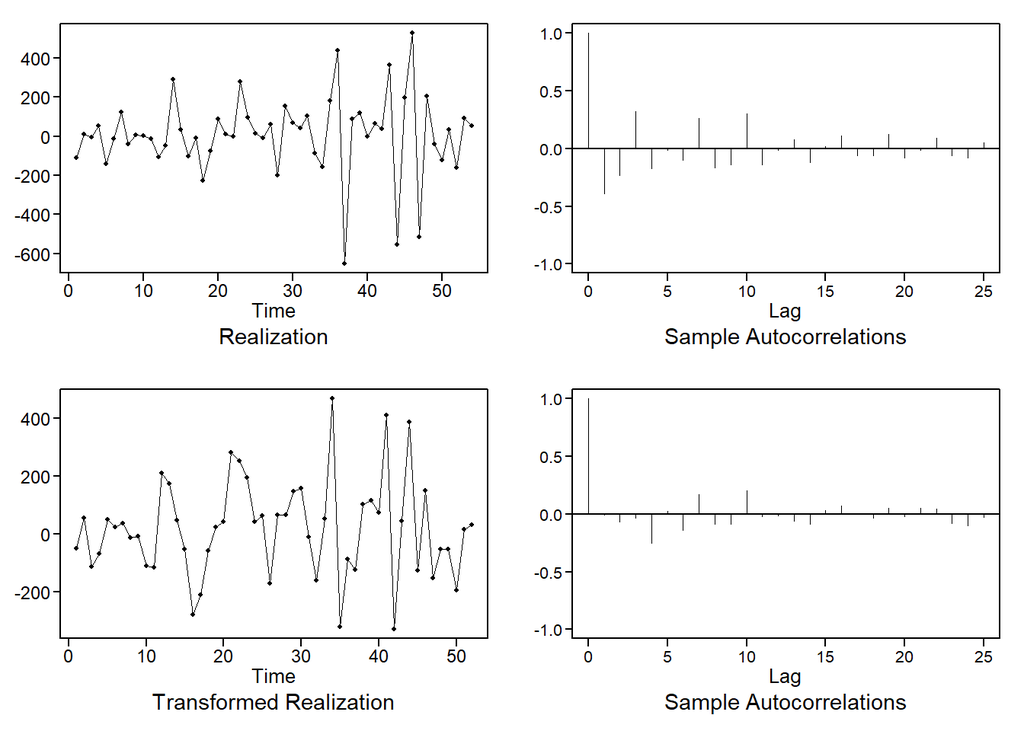

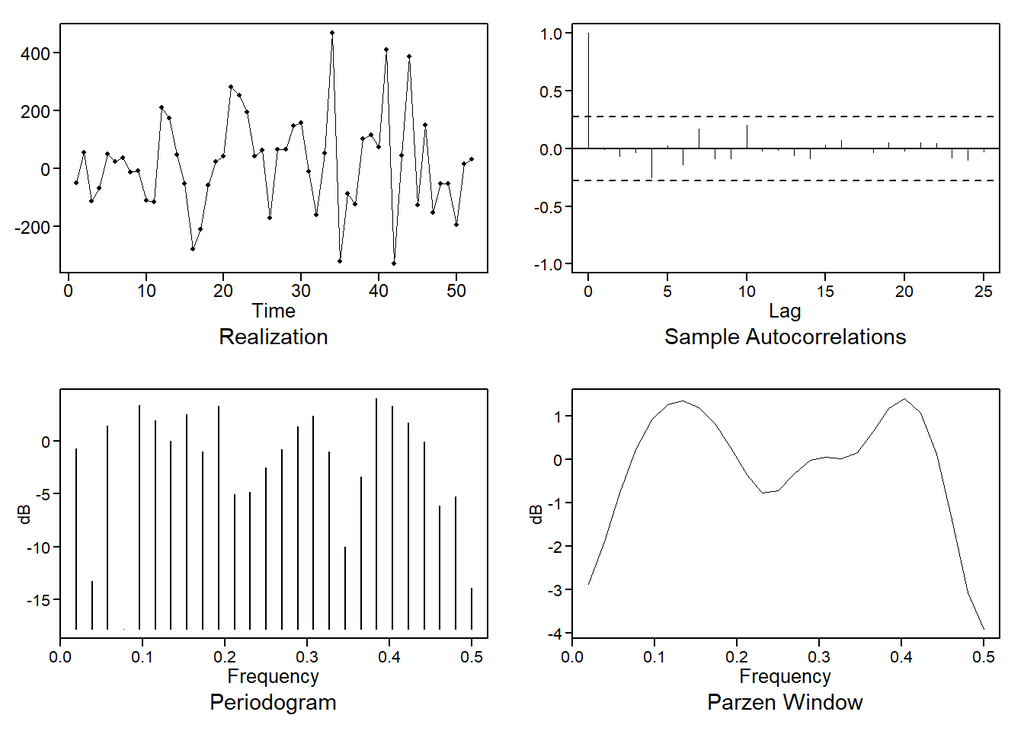

```
## $autplt
##  [1]  1.000000000 -0.005120699 -0.068988787 -0.034496369 -0.252528828
##  [6]  0.027564264 -0.136754080  0.170687732 -0.086512656 -0.086176281
## [11]  0.206570740 -0.017545286 -0.011178394 -0.062624166 -0.087824748
## [16]  0.035334486  0.070465491 -0.002576489 -0.035957812  0.049568428
## [21] -0.023575554  0.052659502  0.044986510 -0.078303443 -0.098494314
## [26] -0.028161015
##
## $freq
##  [1] 0.01923077 0.03846154 0.05769231 0.07692308 0.09615385 0.11538462
##  [7] 0.13461538 0.15384615 0.17307692 0.19230769 0.21153846 0.23076923
## [13] 0.25000000 0.26923077 0.28846154 0.30769231 0.32692308 0.34615385
## [19] 0.36538462 0.38461538 0.40384615 0.42307692 0.44230769 0.46153846
## [25] 0.48076923 0.50000000
##
## $db
##  [1]  -0.74335922 -13.29553883   1.43537412 -17.82671533   3.39253070
##  [6]   1.94800178  -0.02308725   2.52158975  -0.96473373   3.30648271
## [11]  -5.01890083  -4.85620520  -2.49545842  -0.74802525   1.36650303
## [16]   2.38609281  -0.99382806  -9.99004635  -3.40125675   4.01565860
## [21]   3.34792084   1.74015444  -0.04615424  -6.09851512  -5.27969807
## [26] -13.89009702
##
## $dbz
##  [1] -2.86809689 -1.89487540 -0.75916102  0.22486184  0.91047609  1.27241999
##  [7]  1.34949747  1.19097615  0.82198252  0.26699111 -0.35473513 -0.76077957
## [13] -0.70702568 -0.33406687 -0.01344184  0.06198055  0.01762746  0.17095567
## [19]  0.64915910  1.18303171  1.40126931  1.07643236  0.12946405 -1.37790806
## [25] -3.07039550 -3.91562802
```

```r
## ACFs of  differenced  data with AR(2) shows white
plotts.sample.wge(Coviddata_WA.d1.AR2, arlimits = T)
```

```r
ljung.wge(Coviddata_WA.d1.AR2, K=24)
```

```
## Obs -0.005120699 -0.06898879 -0.03449637 -0.2525288 0.02756426 -0.1367541 0.1706877 -0.08651266 -0.08617628 0.2065707 -0.01754529 -0.01117839 -0.06262417 -0.08782475 0.03533449 0.07046549 -0.002576489 -0.03595781 0.04956843 -0.02357555 0.0526595 0.04498651 -0.07830344 -0.09849431
```

```
## $test
## [1] "Ljung-Box test"
##
## $K
## [1] 24
##
## $chi.square
## [1] 14.62459
##
## $df
## [1] 24
##
## $pval
## [1] 0.931264
```

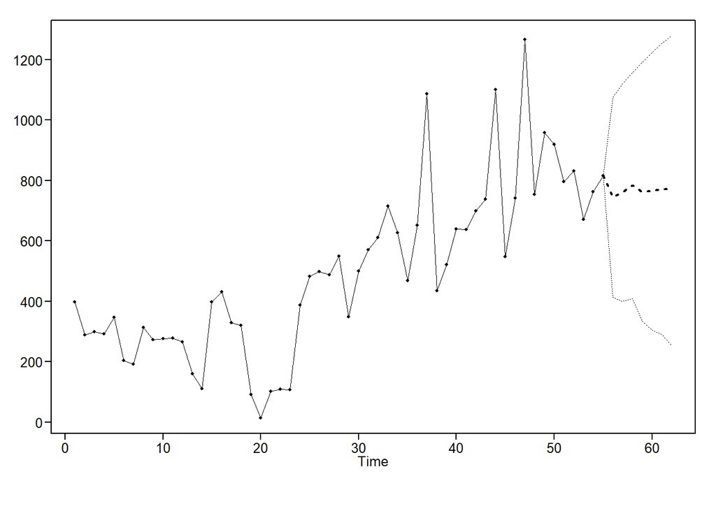

```
## $f
## [1] 744.5920 760.7361 783.1606 763.2082 764.4620 772.6995 767.4675
##
## $ll
## [1] 413.8848 400.3430 408.8297 334.4331 304.3910 291.1005 254.9925
##
## $ul
## [1] 1075.299 1121.129 1157.492 1191.983 1224.533 1254.298 1279.942
##
## $resid
##  [1]    0.000000    0.000000    0.000000  -50.096780   54.965046 -114.527455
##  [7]  -68.280138   50.513541   22.211574   36.023429  -14.553147   -9.190725
## [13] -112.354164 -115.471734  212.117035  174.839524   46.435697  -52.574217
## [19] -280.413582 -211.301857  -59.351653   22.786379   42.552645  283.020934
## [25]  253.279831  194.427972   41.108673   62.058296 -170.904680   66.412883
## [31]   66.589688  148.299148  159.068904  -11.537781 -161.362780   52.517378
## [37]  468.313942 -323.214427  -88.073976 -124.655121  103.028604  114.668173
## [43]   72.368437  412.795787 -331.177937   43.742068  387.086346 -127.931291
## [49]  149.637797 -152.857205  -53.170680  -52.217704 -195.321705   14.994825
## [55]   32.263399
##
## $wnv
## [1] 28469.2
##
## $se
## [1] 168.7282 183.8740 190.9851 218.7628 234.7301 245.7138 261.4668
##
## $psi
## [1] 0.4331132 0.3059963 0.6322932 0.5043289 0.4305333 0.5297562 0.5066037
##
## $ptot
## [1] 3
##
## $phitot
## [1] 0.4331132 0.1184092 0.4484776
```

```r
## $pval  :0.931

## Ljung box test with K=24  fail to reject null hypothesis which is evident that the residuals are white

# Next 7 forecasts with AR(2) model
fore.aruma.wge(Coviddata_WA$new_cases, phi = ar2.est$phi,d=1, n.ahead = 7, limits=T)
```

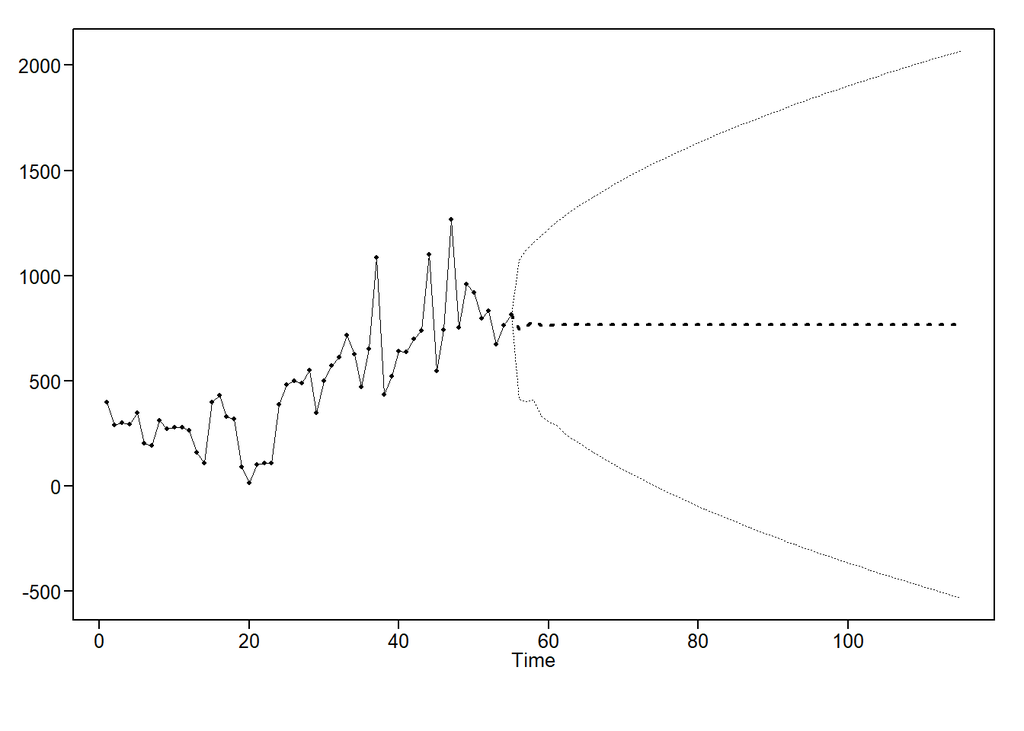

```
## $f
##  [1] 744.5920 760.7361 783.1606 763.2082 764.4620 772.6995 767.4675 766.7391
##  [9] 769.4984 768.2609 767.7249 768.5838 768.3373 768.0918 768.3415 768.3100
## [17] 768.2159 768.2834 768.2874 768.2548 768.2715 768.2766 768.2663 768.2698
## [25] 768.2725 768.2694 768.2699 768.2710 768.2701 768.2702 768.2705 768.2703
## [33] 768.2703 768.2704 768.2703 768.2703 768.2704 768.2703 768.2703 768.2703
## [41] 768.2703 768.2703 768.2703 768.2703 768.2703 768.2703 768.2703 768.2703
## [49] 768.2703 768.2703 768.2703 768.2703 768.2703 768.2703 768.2703 768.2703
## [57] 768.2703 768.2703 768.2703 768.2703
##
## $ll
##  [1]  413.884793  400.343016  408.829734  334.433117  304.391004  291.100505
##  [7]  254.992514  227.573669  207.894315  182.501568  158.939169  138.605126
## [13]  117.241705   96.463082   77.093564   57.850604   38.995569   20.860702
## [19]    3.070242  -14.375980  -31.370014  -48.024206  -64.369265  -80.379915
```

[output cut: 58 more lines]

```r
# Next 60 forecasts with AR(2) model
fore.aruma.wge(Coviddata_WA$new_cases, phi = ar2.est$phi,d=1, n.ahead = 60, limits=T)
```

```r
# ASE
Coviddata_WA.d1.ar2.forecasts = fore.aruma.wge(Coviddata_WA$new_cases, phi = ar2.est$phi, d=1,lastn = T, n.ahead = 7)
```

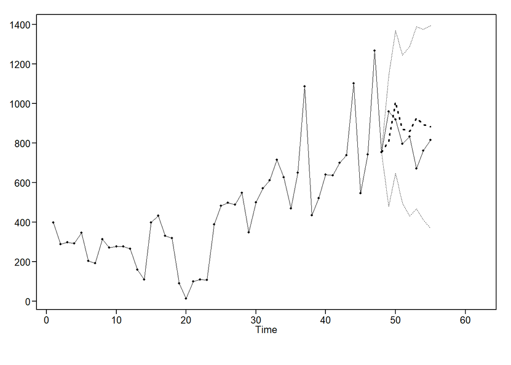

```r
Coviddata_WA.d1.ar2.ase = mean((Coviddata_WA$new_cases[(49-7+1):55] - Coviddata_WA.d1.ar2.forecasts$f)^2)
Coviddata_WA.d1.ar2.ase
```

```
## [1] 30765.94
```

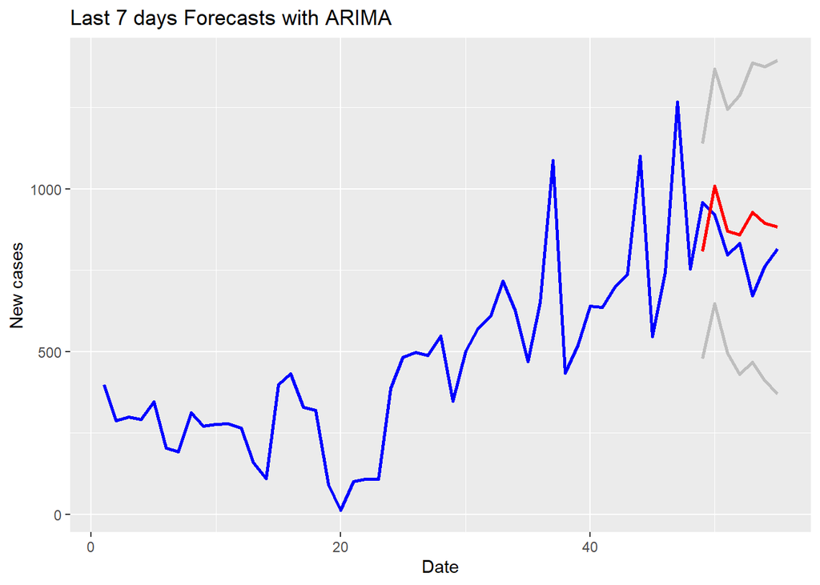

```r
# ASE : 30765.94
#Plot
ggplot() +
  geom_line(aes(x=seq(1,55,1), y=Coviddata_WA$new_cases, group = 1),
             color = "blue", size=1) +
  geom_line(aes(x=seq(49,55,1), y=Coviddata_WA.d1.ar2.forecasts$f, group = 1),
             color = "red", size=1) +
  geom_line(aes(x=seq(49,55,1), y=Coviddata_WA.d1.ar2.forecasts$ll, group = 1),
             color = "grey", size=1) +
  geom_line(aes(x=seq(49,55,1), y=Coviddata_WA.d1.ar2.forecasts$ul, group = 1),
             color = "grey", size=1) +
  xlab("Date") +
  ylab("New cases") +
  ggtitle("Last 7 days Forecasts with ARIMA")
```

```r
# Rolling window ASE

trainingSize = 20
horizon = 7
d1.ar2.ASEHolder = numeric()

for( i in 1:(55-(trainingSize + horizon) + 1))
{

  forecasts = fore.aruma.wge(Coviddata_WA$new_cases[i:(i+(trainingSize-1))],
                            phi = ar2.est$phi, d=1,n.ahead = horizon, plot=F)

  ASE = mean((Coviddata_WA$new_cases[(trainingSize+i):(trainingSize+ i + (horizon) - 1)] - forecasts$f)^2)

  d1.ar2.ASEHolder[i] = ASE

}

d1.ar2.ASEHolder
```

```
##  [1]  75139.53 119881.47 123219.77 132720.33  66350.12  26354.81  16857.39
##  [8]  16595.82  13229.95  30718.70  75210.42  63670.96  48162.09  40168.94
## [15]  40260.79  40628.10  39329.87  50533.50  35425.82  40766.54 126436.93
## [22] 103314.68  96853.45  89513.26  36527.54  37140.41  32688.58  29997.75
## [29]  17637.65
```

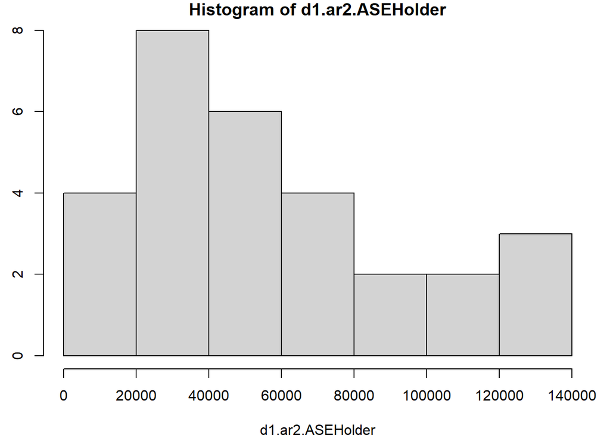

```r
hist(d1.ar2.ASEHolder)
```

```r
d1.ar2.WindowedASE = mean(d1.ar2.ASEHolder)

summary(d1.ar2.ASEHolder)
```

```
##    Min. 1st Qu.  Median    Mean 3rd Qu.    Max.
##   13230   32689   40628   57425   75210  132720
```

```r
d1.ar2.WindowedASE
```

```
## [1] 57425.35
```

```r
## Rolling window ASE :57425.35
```

```r
# univariate MLP model
fit.mlp.uni = mlp(ts(Coviddata_WA$new_cases),reps = 100,comb = "mean")
fit.mlp.uni
```

```
## MLP fit with 5 hidden nodes and 100 repetitions.
## Univariate lags: (1,3)
## Forecast combined using the mean operator.
## MSE: 12365.1831.
```

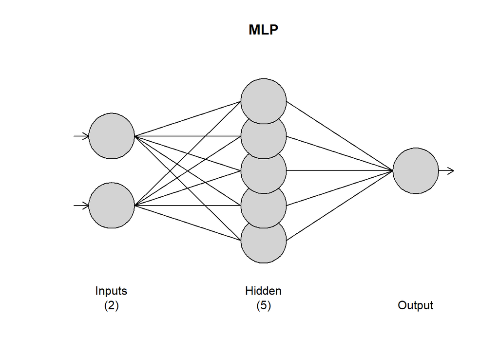

```r
plot(fit.mlp.uni)
```

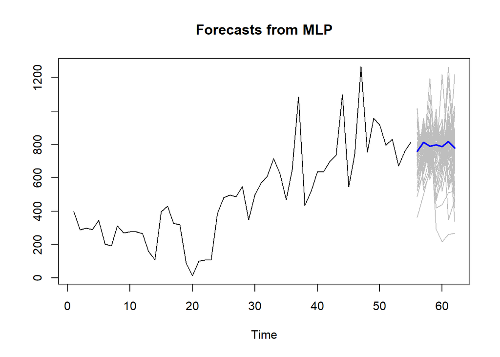

```r
# Forecasting next 7 days
uni.fore7.mlp = forecast(fit.mlp.uni, h = 7)
plot(uni.fore7.mlp)
```

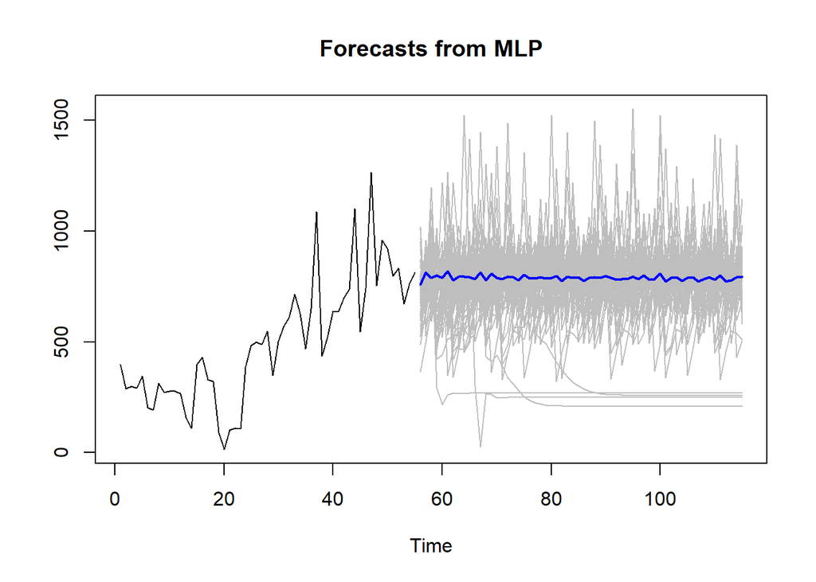

```r
# Forecasting next 60 days
uni.fore60.mlp = forecast(fit.mlp.uni, h = 60)
plot(uni.fore60.mlp)
```

```r
# ASE for entire data set (Rolling window ASE)
NN_uni_fitted = fitted(fit.mlp.uni)
fit.mlp.uni$fitted
```

```
## Time Series:
## Start = 4
## End = 55
## Frequency = 1
##  [1]  279.1830  272.4853  320.7569  219.9136  215.0386  293.9509  261.1995
##  [8]  261.3047  262.3718  254.0320  202.5533  186.7002  385.2760  421.4270
## [15]  305.1961  296.6723  161.2429  141.3811  186.0252  187.9699  187.8844
## [22]  377.7475  471.6548  495.0244  491.3139  561.1467  337.5008  523.8142
## [29]  576.4908  646.9629  729.5066  697.7536  600.0442  807.4418  507.5102
## [36]  496.4104  715.1233  666.1421  681.7936  846.1057  867.1826  644.8373
## [43]  704.6022 1089.3002  668.3322  877.5950  908.0451  701.1759  883.0945
## [50]  812.7294  862.1835  886.9016
```

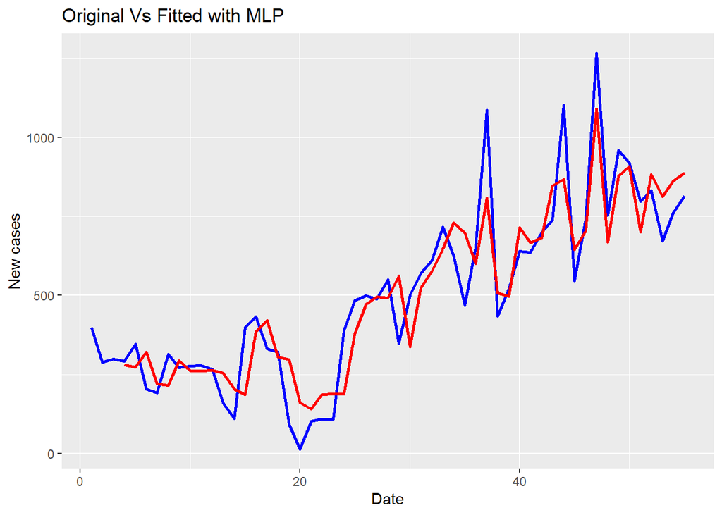

```r
# Plot with original and fitted values
ggplot() +
  geom_line(aes(x=seq(1,55,1), y=Coviddata_WA$new_cases, group = 1),
             color = "blue", size=1) +
  geom_line(aes(x=seq(4,55,1), y=NN_uni_fitted, group = 1),
             color = "red", size=1) +
  xlab("Date") +
  ylab("New cases") +
  ggtitle("Original Vs Fitted with MLP")
```

```r
NN_uni_ase = mean((Coviddata_WA$new_cases[4:55]-NN_uni_fitted)^2)
NN_uni_ase
```

```
## [1] 12365.18
```

```r
# 13239.29
```

## ARIMA and MLP Univariate Model Comparison:

With respect to rolling window ASE, MLP model has lowest ASE than ARIMA model, fitted values also follows the trend in the original realization

```r
ensemble_uni  = (Coviddata_WA.d1.ar2.forecasts$f + NN_uni_fitted[46:52])/2
ensemble_uni
```

```
## [1] 843.4786 958.0461 785.8812 871.2500 870.0606 878.0246 884.6412
```

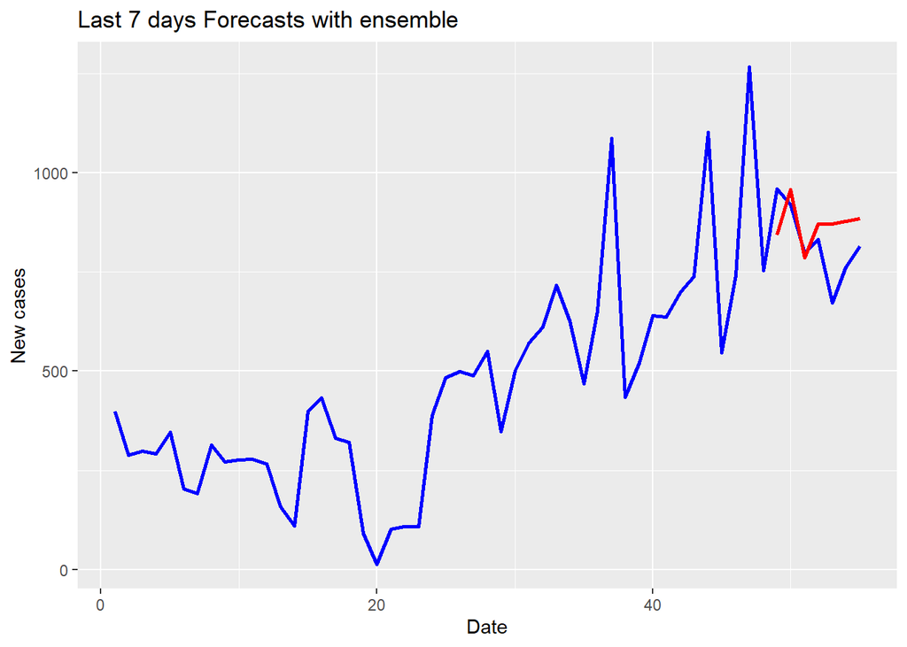

```r
#Plot
ggplot() +
  geom_line(aes(x=seq(1,55,1), y=Coviddata_WA$new_cases, group = 1),
             color = "blue", size=1) +
  geom_line(aes(x=seq(49,55,1), y=ensemble_uni, group = 1),
             color = "red", size=1) +
  xlab("Date") +
  ylab("New cases") +
  ggtitle("Last 7 days Forecasts with ensemble")
```

```r
ensemble_uni_ASE = mean((Coviddata_WA$new_cases[49:55] - ensemble_uni)^2)
ensemble_uni_ASE
```

```
## [1] 10570.93
```

```r
## 9300.102
```

### MULTIVARIATE ANALYSIS

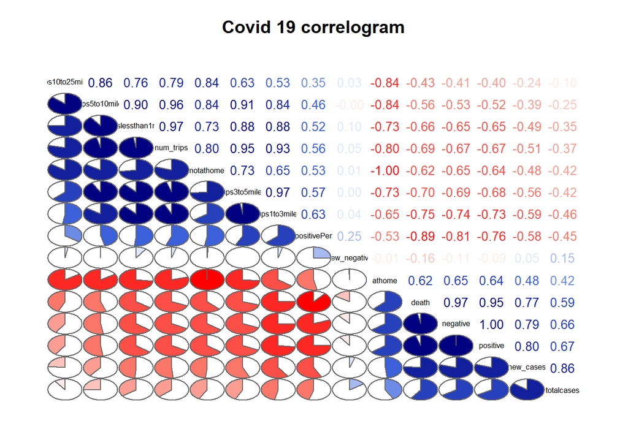

```r
corrgram(Covid_mobility_WA, order=TRUE,
         upper.panel=panel.cor, lower.panel=panel.pie, main="Covid 19 correlogram")
```

```r
str(Covid_mobility_WA)
```

```
## 'data.frame':    55 obs. of  17 variables:
##  $ date              : Date, format: "2020-06-01" "2020-06-02" ...
##  $ state             : chr  "WA" "WA" "WA" "WA" ...
##  $ positive          : int  23798 24086 24385 24677 25023 25227 25419 25732 26004 26281 ...
##  $ negative          : int  320527 326646 331675 335972 341885 345430 347610 355573 365086 376364 ...
##  $ death             : int  1118 1124 1129 1135 1138 1149 1153 1159 1161 1176 ...
##  $ new_cases         : num  398 288 299 292 346 204 192 313 272 277 ...
##  $ positivePer       : num  6.91 6.87 6.85 6.84 6.82 ...
##  $ new_negative      : int  320527 6119 5029 4297 5913 3545 2180 7963 9513 11278 ...
##  $ totalcases        : num  11398 6407 5328 4589 6259 ...
##  $ athome            : num  1898930 1947264 1805964 1818122 1795842 ...
##  $ notathome         : num  5636661 5588327 5729627 5717469 5739749 ...
##  $ num_trips         : num  22247684 21889433 23370481 22675444 23284067 ...
##  $ tripslessthan1mile: num  6727382 6518441 7022670 6778866 6927186 ...
##  $ trips1to3miles    : num  5385845 5207970 5640039 5379178 5526191 ...
##  $ trips3to5miles    : num  2422793 2337207 2528537 2451863 2566421 ...
##  $ trips5to10miles   : num  3034697 3001413 3209304 3124333 3246005 ...
##  $ trips10to25miles  : num  3102042 3182330 3308452 3276912 3304250 ...
```

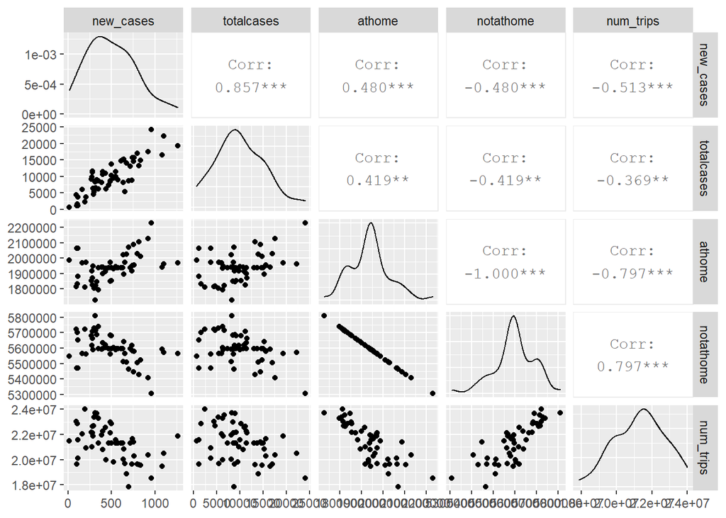

```r
Covid_mobility_WA_New1 = Covid_mobility_WA[ , c('new_cases', 'totalcases', 'athome', 'notathome', 'num_trips')]

Covid_mobility_WA_New2 = Covid_mobility_WA[ , c('new_cases', 'tripslessthan1mile', 'trips1to3miles', 'trips3to5miles', 'trips5to10miles', 'trips10to25miles')]

ggpairs(Covid_mobility_WA_New1)
```

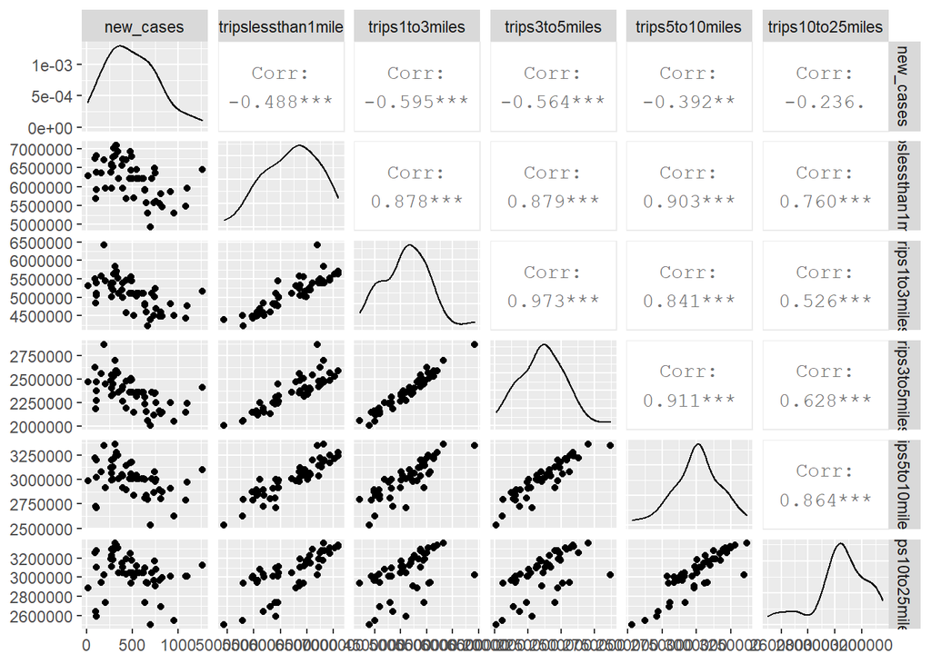

```r
ggpairs(Covid_mobility_WA_New2)
```

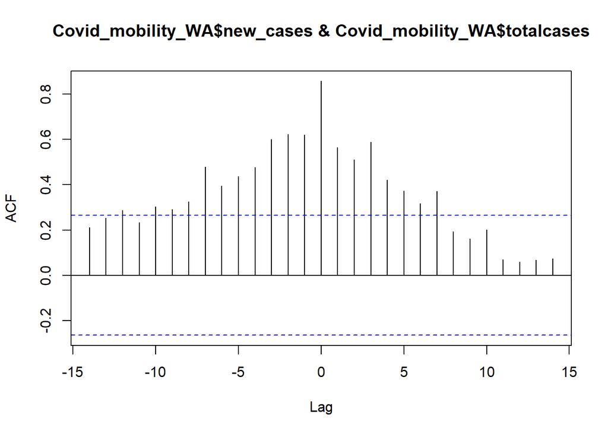

```r
ccf(Covid_mobility_WA$new_cases, Covid_mobility_WA$totalcases)
```

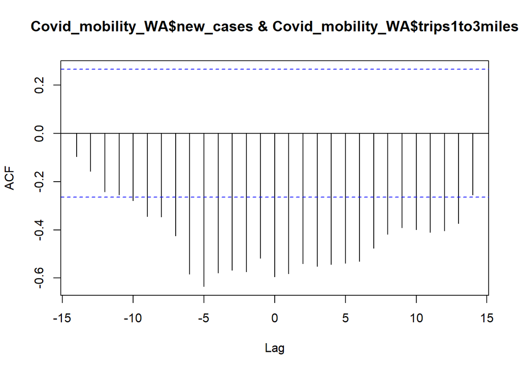

```r
# lag 0

ccf(Covid_mobility_WA$new_cases, Covid_mobility_WA$trips1to3miles)
```

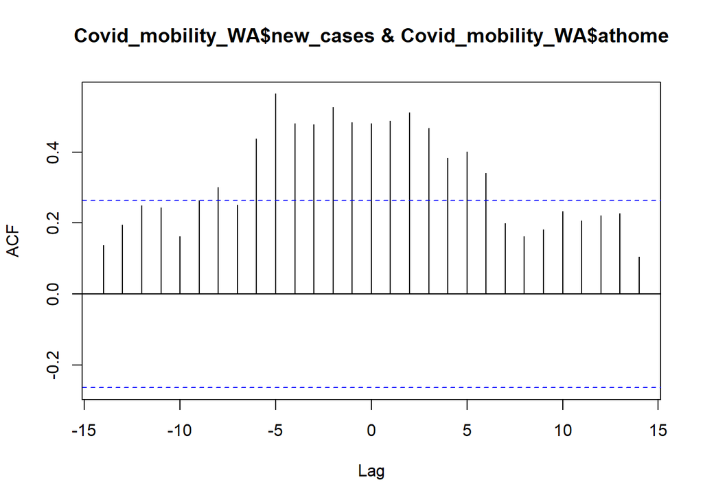

```r
# lag -5

ccf(Covid_mobility_WA$new_cases, Covid_mobility_WA$athome)
```

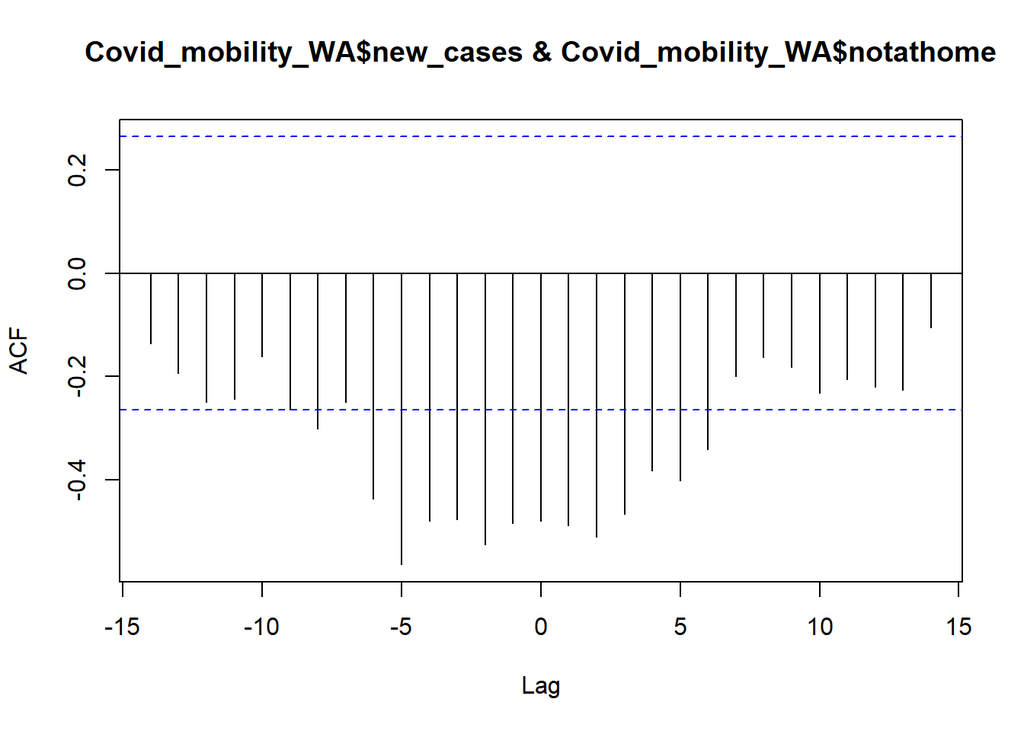

```r
# lag -5

ccf(Covid_mobility_WA$new_cases, Covid_mobility_WA$notathome)
```

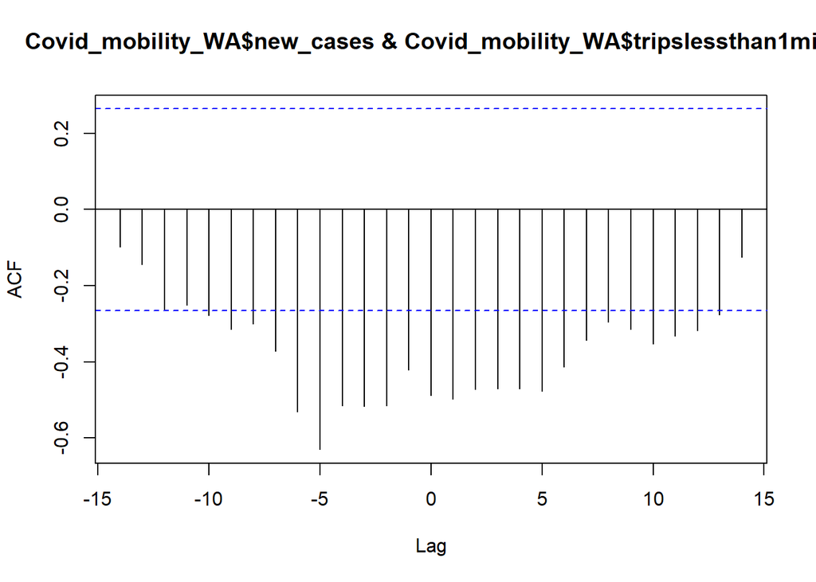

```r
# lag -5

ccf(Covid_mobility_WA$new_cases, Covid_mobility_WA$tripslessthan1mile)
```

```r
# lag -5
```

Based on the correlogram, new cases is correlated to total cases (0.86) new cases is correlated with trips between 3 to 5 miles new cases is correlated with trips between 1 to 3 miles new cases is correlated with trips less than 1 mile

All mobility variables are correlated with number of new cases, but all of them are highly correlated with each other, including them in the model might result in multicollinearity issue. So decided to include one of the highly correlated mobility variable in the model.

```r
var_data = cbind(Covid_mobility_WA$new_cases, Covid_mobility_WA$totalcases,  Covid_mobility_WA$trips1to3miles)

#VARSelect
VARselect(var_data,lag.max = 10, type = "both")
```

```
## $selection
## AIC(n)  HQ(n)  SC(n) FPE(n)
##     10      1      1      2
##
## $criteria
##                   1            2            3            4            5
## AIC(n) 5.101852e+01 5.099262e+01 5.110706e+01 5.130298e+01 5.144345e+01
## HQ(n)  5.124302e+01 5.135183e+01 5.160096e+01 5.193158e+01 5.220675e+01
## SC(n)  5.162074e+01 5.195618e+01 5.243194e+01 5.298920e+01 5.349100e+01
## FPE(n) 1.439662e+22 1.415110e+22 1.616872e+22 2.034178e+22 2.471185e+22
##                   6            7            8            9           10
## AIC(n) 5.159998e+01 5.139247e+01 5.100054e+01 5.091528e+01 5.085177e+01
## HQ(n)  5.249799e+01 5.242518e+01 5.216795e+01 5.221739e+01 5.228858e+01
## SC(n)  5.400887e+01 5.416268e+01 5.413208e+01 5.440816e+01 5.470598e+01
## FPE(n) 3.136098e+22 2.870039e+22 2.297266e+22 2.680943e+22 3.542371e+22
```

```r
#VAR with p = 10 lowest AIC
new_cases_VAR_both = VAR(var_data,type = "both",p = 10)
```

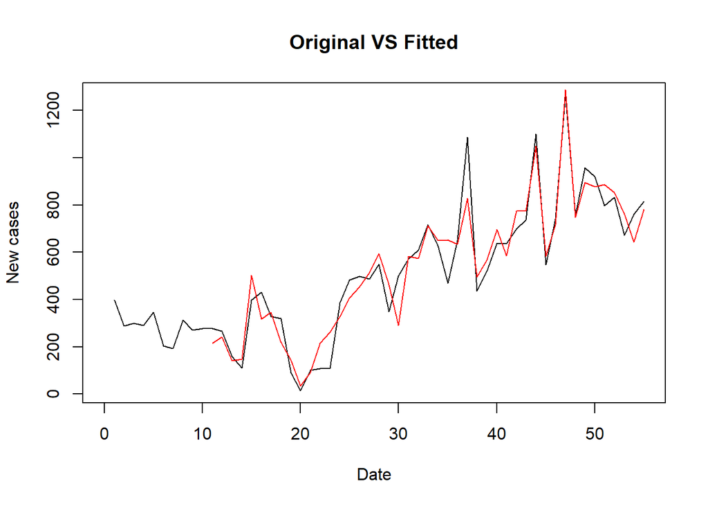

```r
# predicted values
var_both_fitted = fitted(new_cases_VAR_both)

# Plot
{plot(seq(1,55,1), Coviddata_WA$new_cases, type = "l",xlim = c(0,55), ylab = "New cases",
     main = "Original VS Fitted", xlab="Date",)
lines(seq(11, 55,1), var_both_fitted[,1], type = "l", col = "red")}
```

```r
var_both_ase = mean((Coviddata_WA$new_cases[11:55]-var_both_fitted[,1])^2)
var_both_ase
```

```
## [1] 6966.21
```

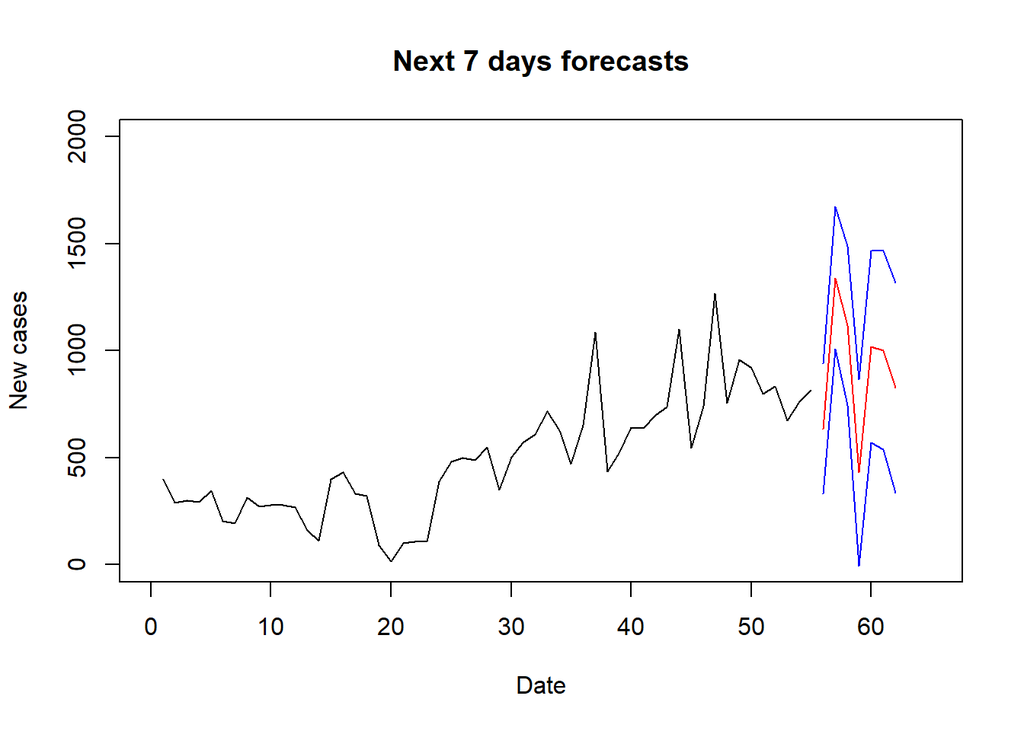

```r
# Rolling window ASE : 6966.21

#### 7 day Forecast
preds_var_both_7=predict(new_cases_VAR_both,n.ahead=7)

# Plot
{plot(seq(1,55,1), Coviddata_WA$new_cases, type = "l",xlim = c(0,65), ylab = "New cases",
     main = "Next 7 days forecasts", xlab="Date", ylim = c(0,2000),)
lines(seq(56, 62,1), preds_var_both_7$fcst$y1[,1], type = "l", col = "red")
lines(seq(56, 62,1), preds_var_both_7$fcst$y1[,2], type = "l", col = "blue")
lines(seq(56, 62,1), preds_var_both_7$fcst$y1[,3], type = "l", col = "blue")}
```

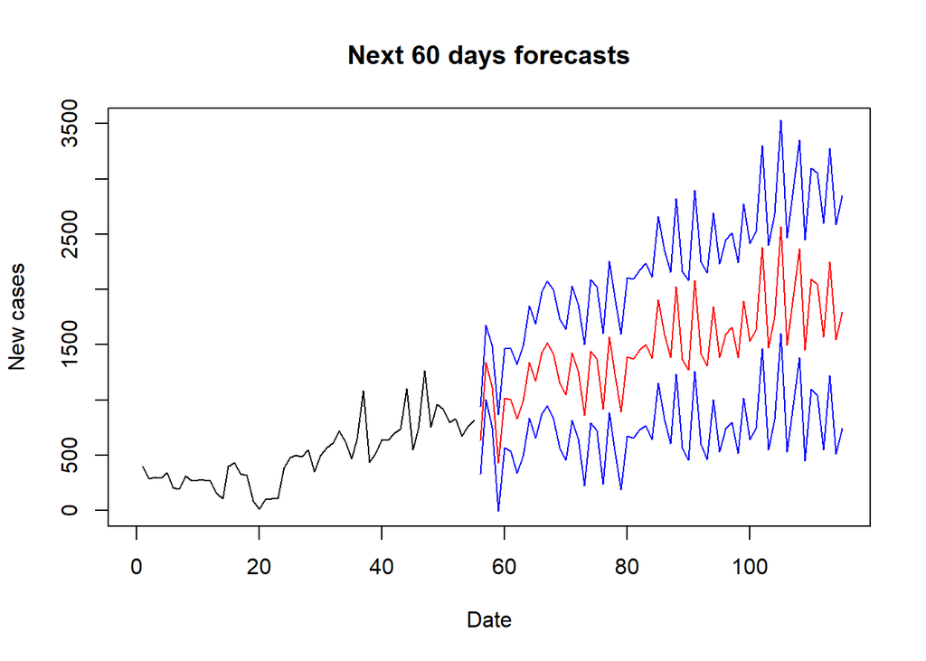

```r
#### 60 day Forecast

preds_var_both_60=predict(new_cases_VAR_both,n.ahead=60)

# Plot
{plot(seq(1,55,1), Coviddata_WA$new_cases, type = "l",xlim = c(0,115),
     ylim = c(0,3500),
     xlab="Date",
     ylab = "New cases",
     main = "Next 60 days forecasts")
lines(seq(56, 115,1), preds_var_both_60$fcst$y1[,1], type = "l", col = "red")
lines(seq(56, 115,1), preds_var_both_60$fcst$y1[,2], type = "l", col = "blue")
lines(seq(56, 115,1), preds_var_both_60$fcst$y1[,3], type = "l", col = "blue")}
```

```r
MLP_data = cbind(Covid_mobility_WA$new_cases, Covid_mobility_WA$totalcases,  Covid_mobility_WA$trips1to3miles)

#####   Forecasting
MLP_Coviddata_WA = Covid_mobility_WA
MLP_Coviddata_WA_DF = data.frame(totalcases = ts(MLP_Coviddata_WA$totalcases),
                                 trips1to3miles = ts(MLP_Coviddata_WA$trips1to3miles))

# forecasting total cases
fit.mlp_total = mlp(ts(MLP_Coviddata_WA$totalcases),reps = 100,comb = "median")
fit.mlp_total
```

```
## MLP fit with 5 hidden nodes and 100 repetitions.
## Univariate lags: (1,2)
## Forecast combined using the median operator.
## MSE: 12421900.3669.
```

```r
plot(fit.mlp_total)
fore.mlp_7days_total = forecast(fit.mlp_total, h = 7)
fore.mlp_60days_total = forecast(fit.mlp_total, h = 60)

# forecasting trips 1 to 3 miles
fit.mlp_trips1to3miles = mlp(ts(MLP_Coviddata_WA$trips1to3miles),reps = 100,comb = "median")
fit.mlp_trips1to3miles
```

[output not shown]

```
## MLP fit with 5 hidden nodes and 100 repetitions.
## Univariate lags: (1,4)
## Forecast combined using the median operator.
## MSE: 73839743788.1232.
```

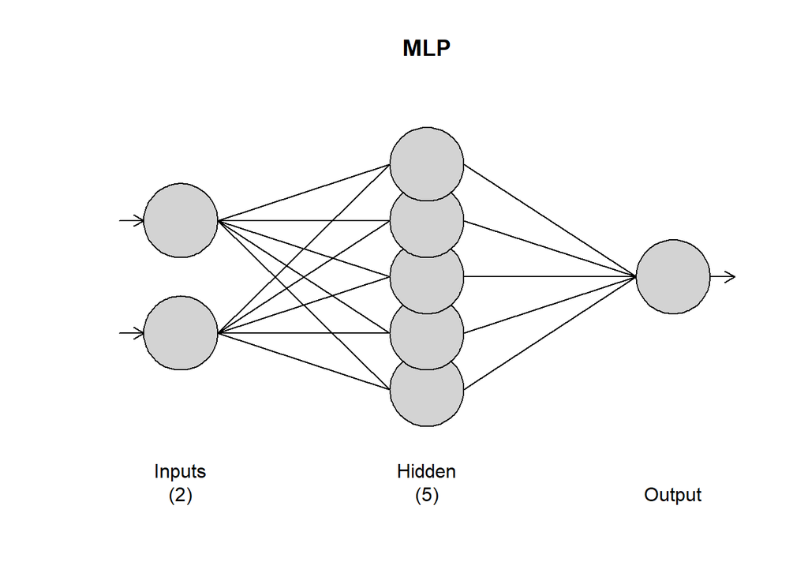

```r
plot(fit.mlp_trips1to3miles)
```

```r
fore.mlp_7days_trips1to3miles = forecast(fit.mlp_trips1to3miles, h = 7)

fore.mlp_60days_trips1to3miles = forecast(fit.mlp_trips1to3miles, h = 60)

## multivariate forecasting next 7 days
fit.mlp = mlp(ts(MLP_Coviddata_WA$new_cases),reps = 100,comb = "median",
              xreg = MLP_Coviddata_WA_DF)
fit.mlp
```

```
## MLP fit with 5 hidden nodes and 100 repetitions.
## Univariate lags: (1,3)
## 1 regressor included.
## - Regressor 1 lags: (1)
## Forecast combined using the median operator.
## MSE: 9338.0376.
```

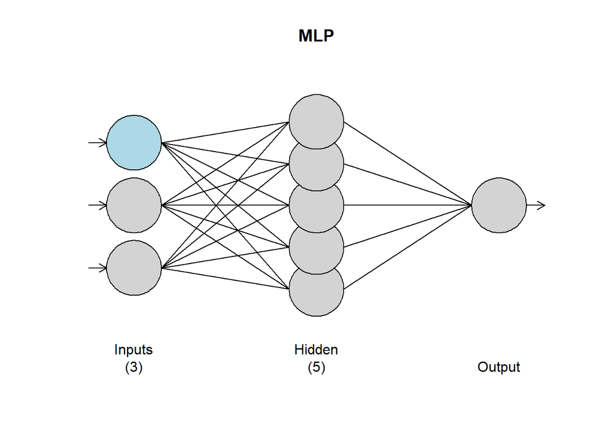

```r
plot(fit.mlp)
```